# Risk Factor Analysis

## Outcome Variable

**Outcome Variable:** stunted

## Predictor Variables

**Intervention Variable:** hhwealth_quart

**Adjustment Set:**

unadjusted

## Stratifying Variables

The analysis was stratified on these variable(s):

- agecat
- studyid
- country

## Data Summary

| agecat | studyid | country | A | n | nA | nAY0 | nAY1 |
| --- | --- | --- | --- | --- | --- | --- | --- |
| Birth | ki0047075b-MAL-ED | BANGLADESH | Wealth Q4 | 82 | 26 | 23 | 3 |
| Birth | ki0047075b-MAL-ED | BANGLADESH | Wealth Q1 | 82 | 4 | 3 | 1 |
| Birth | ki0047075b-MAL-ED | BANGLADESH | Wealth Q2 | 82 | 15 | 13 | 2 |
| Birth | ki0047075b-MAL-ED | BANGLADESH | Wealth Q3 | 82 | 37 | 27 | 10 |
| Birth | ki0047075b-MAL-ED | BRAZIL | Wealth Q4 | 3 | 2 | 1 | 1 |
| Birth | ki0047075b-MAL-ED | BRAZIL | Wealth Q1 | 3 | 0 | 0 | 0 |
| Birth | ki0047075b-MAL-ED | BRAZIL | Wealth Q2 | 3 | 1 | 0 | 1 |
| Birth | ki0047075b-MAL-ED | BRAZIL | Wealth Q3 | 3 | 0 | 0 | 0 |
| Birth | ki0047075b-MAL-ED | INDIA | Wealth Q4 | 55 | 21 | 16 | 5 |
| Birth | ki0047075b-MAL-ED | INDIA | Wealth Q1 | 55 | 1 | 1 | 0 |
| Birth | ki0047075b-MAL-ED | INDIA | Wealth Q2 | 55 | 9 | 7 | 2 |
| Birth | ki0047075b-MAL-ED | INDIA | Wealth Q3 | 55 | 24 | 18 | 6 |
| Birth | ki0047075b-MAL-ED | NEPAL | Wealth Q4 | 31 | 14 | 11 | 3 |
| Birth | ki0047075b-MAL-ED | NEPAL | Wealth Q1 | 31 | 11 | 9 | 2 |
| Birth | ki0047075b-MAL-ED | NEPAL | Wealth Q2 | 31 | 4 | 4 | 0 |
| Birth | ki0047075b-MAL-ED | NEPAL | Wealth Q3 | 31 | 2 | 2 | 0 |
| Birth | ki0047075b-MAL-ED | PERU | Wealth Q4 | 36 | 1 | 1 | 0 |
| Birth | ki0047075b-MAL-ED | PERU | Wealth Q1 | 36 | 23 | 19 | 4 |
| Birth | ki0047075b-MAL-ED | PERU | Wealth Q2 | 36 | 11 | 9 | 2 |
| Birth | ki0047075b-MAL-ED | PERU | Wealth Q3 | 36 | 1 | 1 | 0 |
| Birth | ki0047075b-MAL-ED | SOUTH AFRICA | Wealth Q4 | 61 | 12 | 12 | 0 |
| Birth | ki0047075b-MAL-ED | SOUTH AFRICA | Wealth Q1 | 61 | 10 | 9 | 1 |
| Birth | ki0047075b-MAL-ED | SOUTH AFRICA | Wealth Q2 | 61 | 22 | 21 | 1 |
| Birth | ki0047075b-MAL-ED | SOUTH AFRICA | Wealth Q3 | 61 | 17 | 14 | 3 |
| Birth | ki0047075b-MAL-ED | TANZANIA, UNITED REPUBLIC OF | Wealth Q4 | 23 | 0 | 0 | 0 |
| Birth | ki0047075b-MAL-ED | TANZANIA, UNITED REPUBLIC OF | Wealth Q1 | 23 | 16 | 14 | 2 |
| Birth | ki0047075b-MAL-ED | TANZANIA, UNITED REPUBLIC OF | Wealth Q2 | 23 | 7 | 7 | 0 |
| Birth | ki0047075b-MAL-ED | TANZANIA, UNITED REPUBLIC OF | Wealth Q3 | 23 | 0 | 0 | 0 |
| Birth | ki1000108-CMC-V-BCS-2002 | INDIA | Wealth Q4 | 90 | 31 | 24 | 7 |
| Birth | ki1000108-CMC-V-BCS-2002 | INDIA | Wealth Q1 | 90 | 14 | 12 | 2 |

[output cut: 398 more lines]

The following strata were considered:

- agecat: 12 months, studyid: ki0047075b-MAL-ED, country: BANGLADESH
- agecat: 12 months, studyid: ki0047075b-MAL-ED, country: BRAZIL
- agecat: 12 months, studyid: ki0047075b-MAL-ED, country: INDIA
- agecat: 12 months, studyid: ki0047075b-MAL-ED, country: NEPAL
- agecat: 12 months, studyid: ki0047075b-MAL-ED, country: PERU
- agecat: 12 months, studyid: ki0047075b-MAL-ED, country: SOUTH AFRICA
- agecat: 12 months, studyid: ki0047075b-MAL-ED, country: TANZANIA, UNITED REPUBLIC OF
- agecat: 12 months, studyid: ki1000108-CMC-V-BCS-2002, country: INDIA
- agecat: 12 months, studyid: ki1000108-IRC, country: INDIA
- agecat: 12 months, studyid: ki1017093b-PROVIDE, country: BANGLADESH
- agecat: 12 months, studyid: ki1066203-TanzaniaChild2, country: TANZANIA, UNITED REPUBLIC OF
- agecat: 12 months, studyid: ki1113344-GMS-Nepal, country: NEPAL
- agecat: 12 months, studyid: ki1114097-CONTENT, country: PERU
- agecat: 12 months, studyid: ki1135781-COHORTS, country: GUATEMALA
- agecat: 12 months, studyid: ki1135781-COHORTS, country: PHILIPPINES
- agecat: 12 months, studyid: ki1148112-LCNI-5, country: MALAWI
- agecat: 18 months, studyid: ki0047075b-MAL-ED, country: BANGLADESH
- agecat: 18 months, studyid: ki0047075b-MAL-ED, country: BRAZIL
- agecat: 18 months, studyid: ki0047075b-MAL-ED, country: INDIA
- agecat: 18 months, studyid: ki0047075b-MAL-ED, country: NEPAL
- agecat: 18 months, studyid: ki0047075b-MAL-ED, country: PERU
- agecat: 18 months, studyid: ki0047075b-MAL-ED, country: SOUTH AFRICA
- agecat: 18 months, studyid: ki0047075b-MAL-ED, country: TANZANIA, UNITED REPUBLIC OF
- agecat: 18 months, studyid: ki1000108-CMC-V-BCS-2002, country: INDIA
- agecat: 18 months, studyid: ki1000108-IRC, country: INDIA
- agecat: 18 months, studyid: ki1017093b-PROVIDE, country: BANGLADESH
- agecat: 18 months, studyid: ki1066203-TanzaniaChild2, country: TANZANIA, UNITED REPUBLIC OF
- agecat: 18 months, studyid: ki1113344-GMS-Nepal, country: NEPAL
- agecat: 18 months, studyid: ki1114097-CONTENT, country: PERU
- agecat: 18 months, studyid: ki1135781-COHORTS, country: GUATEMALA
- agecat: 18 months, studyid: ki1135781-COHORTS, country: PHILIPPINES
- agecat: 18 months, studyid: ki1148112-LCNI-5, country: MALAWI
- agecat: 24 months, studyid: ki0047075b-MAL-ED, country: BANGLADESH
- agecat: 24 months, studyid: ki0047075b-MAL-ED, country: BRAZIL
- agecat: 24 months, studyid: ki0047075b-MAL-ED, country: INDIA
- agecat: 24 months, studyid: ki0047075b-MAL-ED, country: NEPAL
- agecat: 24 months, studyid: ki0047075b-MAL-ED, country: PERU
- agecat: 24 months, studyid: ki0047075b-MAL-ED, country: SOUTH AFRICA
- agecat: 24 months, studyid: ki0047075b-MAL-ED, country: TANZANIA, UNITED REPUBLIC OF
- agecat: 24 months, studyid: ki1000108-CMC-V-BCS-2002, country: INDIA
- agecat: 24 months, studyid: ki1000108-IRC, country: INDIA
- agecat: 24 months, studyid: ki1017093b-PROVIDE, country: BANGLADESH
- agecat: 24 months, studyid: ki1066203-TanzaniaChild2, country: TANZANIA, UNITED REPUBLIC OF
- agecat: 24 months, studyid: ki1113344-GMS-Nepal, country: NEPAL
- agecat: 24 months, studyid: ki1114097-CONTENT, country: PERU
- agecat: 24 months, studyid: ki1135781-COHORTS, country: GUATEMALA
- agecat: 24 months, studyid: ki1135781-COHORTS, country: PHILIPPINES
- agecat: 24 months, studyid: ki1148112-LCNI-5, country: MALAWI
- agecat: 3 months, studyid: ki0047075b-MAL-ED, country: BANGLADESH
- agecat: 3 months, studyid: ki0047075b-MAL-ED, country: BRAZIL
- agecat: 3 months, studyid: ki0047075b-MAL-ED, country: INDIA
- agecat: 3 months, studyid: ki0047075b-MAL-ED, country: NEPAL
- agecat: 3 months, studyid: ki0047075b-MAL-ED, country: PERU
- agecat: 3 months, studyid: ki0047075b-MAL-ED, country: SOUTH AFRICA
- agecat: 3 months, studyid: ki0047075b-MAL-ED, country: TANZANIA, UNITED REPUBLIC OF
- agecat: 3 months, studyid: ki1000108-CMC-V-BCS-2002, country: INDIA
- agecat: 3 months, studyid: ki1000108-IRC, country: INDIA
- agecat: 3 months, studyid: ki1017093b-PROVIDE, country: BANGLADESH
- agecat: 3 months, studyid: ki1066203-TanzaniaChild2, country: TANZANIA, UNITED REPUBLIC OF
- agecat: 3 months, studyid: ki1113344-GMS-Nepal, country: NEPAL
- agecat: 3 months, studyid: ki1114097-CONTENT, country: PERU
- agecat: 3 months, studyid: ki1135781-COHORTS, country: GUATEMALA
- agecat: 3 months, studyid: ki1135781-COHORTS, country: PHILIPPINES
- agecat: 6 months, studyid: ki0047075b-MAL-ED, country: BANGLADESH
- agecat: 6 months, studyid: ki0047075b-MAL-ED, country: BRAZIL
- agecat: 6 months, studyid: ki0047075b-MAL-ED, country: INDIA
- agecat: 6 months, studyid: ki0047075b-MAL-ED, country: NEPAL
- agecat: 6 months, studyid: ki0047075b-MAL-ED, country: PERU
- agecat: 6 months, studyid: ki0047075b-MAL-ED, country: SOUTH AFRICA
- agecat: 6 months, studyid: ki0047075b-MAL-ED, country: TANZANIA, UNITED REPUBLIC OF
- agecat: 6 months, studyid: ki1000108-CMC-V-BCS-2002, country: INDIA
- agecat: 6 months, studyid: ki1000108-IRC, country: INDIA
- agecat: 6 months, studyid: ki1017093b-PROVIDE, country: BANGLADESH
- agecat: 6 months, studyid: ki1066203-TanzaniaChild2, country: TANZANIA, UNITED REPUBLIC OF
- agecat: 6 months, studyid: ki1113344-GMS-Nepal, country: NEPAL
- agecat: 6 months, studyid: ki1114097-CONTENT, country: PERU
- agecat: 6 months, studyid: ki1135781-COHORTS, country: GUATEMALA
- agecat: 6 months, studyid: ki1135781-COHORTS, country: PHILIPPINES
- agecat: 6 months, studyid: ki1148112-LCNI-5, country: MALAWI
- agecat: 9 months, studyid: ki0047075b-MAL-ED, country: BANGLADESH
- agecat: 9 months, studyid: ki0047075b-MAL-ED, country: BRAZIL
- agecat: 9 months, studyid: ki0047075b-MAL-ED, country: INDIA
- agecat: 9 months, studyid: ki0047075b-MAL-ED, country: NEPAL
- agecat: 9 months, studyid: ki0047075b-MAL-ED, country: PERU
- agecat: 9 months, studyid: ki0047075b-MAL-ED, country: SOUTH AFRICA
- agecat: 9 months, studyid: ki0047075b-MAL-ED, country: TANZANIA, UNITED REPUBLIC OF
- agecat: 9 months, studyid: ki1000108-CMC-V-BCS-2002, country: INDIA
- agecat: 9 months, studyid: ki1000108-IRC, country: INDIA
- agecat: 9 months, studyid: ki1017093b-PROVIDE, country: BANGLADESH
- agecat: 9 months, studyid: ki1066203-TanzaniaChild2, country: TANZANIA, UNITED REPUBLIC OF
- agecat: 9 months, studyid: ki1113344-GMS-Nepal, country: NEPAL
- agecat: 9 months, studyid: ki1114097-CONTENT, country: PERU
- agecat: 9 months, studyid: ki1135781-COHORTS, country: GUATEMALA
- agecat: 9 months, studyid: ki1135781-COHORTS, country: PHILIPPINES
- agecat: 9 months, studyid: ki1148112-LCNI-5, country: MALAWI
- agecat: Birth, studyid: ki0047075b-MAL-ED, country: BANGLADESH
- agecat: Birth, studyid: ki0047075b-MAL-ED, country: BRAZIL
- agecat: Birth, studyid: ki0047075b-MAL-ED, country: INDIA
- agecat: Birth, studyid: ki0047075b-MAL-ED, country: NEPAL
- agecat: Birth, studyid: ki0047075b-MAL-ED, country: PERU
- agecat: Birth, studyid: ki0047075b-MAL-ED, country: SOUTH AFRICA
- agecat: Birth, studyid: ki0047075b-MAL-ED, country: TANZANIA, UNITED REPUBLIC OF
- agecat: Birth, studyid: ki1000108-CMC-V-BCS-2002, country: INDIA
- agecat: Birth, studyid: ki1000108-IRC, country: INDIA
- agecat: Birth, studyid: ki1114097-CONTENT, country: PERU
- agecat: Birth, studyid: ki1135781-COHORTS, country: GUATEMALA
- agecat: Birth, studyid: ki1135781-COHORTS, country: PHILIPPINES

### Dropped Strata

Some strata were dropped due to rare outcomes:

- agecat: Birth, studyid: ki0047075b-MAL-ED, country: BANGLADESH
- agecat: Birth, studyid: ki0047075b-MAL-ED, country: BRAZIL
- agecat: Birth, studyid: ki0047075b-MAL-ED, country: INDIA
- agecat: Birth, studyid: ki0047075b-MAL-ED, country: NEPAL
- agecat: Birth, studyid: ki0047075b-MAL-ED, country: PERU
- agecat: Birth, studyid: ki0047075b-MAL-ED, country: SOUTH AFRICA
- agecat: Birth, studyid: ki0047075b-MAL-ED, country: TANZANIA, UNITED REPUBLIC OF
- agecat: Birth, studyid: ki1000108-CMC-V-BCS-2002, country: INDIA
- agecat: Birth, studyid: ki1114097-CONTENT, country: PERU
- agecat: Birth, studyid: ki1135781-COHORTS, country: GUATEMALA
- agecat: 3 months, studyid: ki0047075b-MAL-ED, country: BANGLADESH
- agecat: 3 months, studyid: ki0047075b-MAL-ED, country: BRAZIL
- agecat: 3 months, studyid: ki0047075b-MAL-ED, country: INDIA
- agecat: 3 months, studyid: ki0047075b-MAL-ED, country: NEPAL
- agecat: 3 months, studyid: ki0047075b-MAL-ED, country: PERU
- agecat: 3 months, studyid: ki0047075b-MAL-ED, country: SOUTH AFRICA
- agecat: 3 months, studyid: ki0047075b-MAL-ED, country: TANZANIA, UNITED REPUBLIC OF
- agecat: 3 months, studyid: ki1114097-CONTENT, country: PERU
- agecat: 6 months, studyid: ki0047075b-MAL-ED, country: BANGLADESH
- agecat: 6 months, studyid: ki0047075b-MAL-ED, country: BRAZIL
- agecat: 6 months, studyid: ki0047075b-MAL-ED, country: INDIA
- agecat: 6 months, studyid: ki0047075b-MAL-ED, country: NEPAL
- agecat: 6 months, studyid: ki0047075b-MAL-ED, country: PERU
- agecat: 6 months, studyid: ki0047075b-MAL-ED, country: SOUTH AFRICA
- agecat: 6 months, studyid: ki0047075b-MAL-ED, country: TANZANIA, UNITED REPUBLIC OF
- agecat: 6 months, studyid: ki1114097-CONTENT, country: PERU
- agecat: 9 months, studyid: ki0047075b-MAL-ED, country: BANGLADESH
- agecat: 9 months, studyid: ki0047075b-MAL-ED, country: BRAZIL
- agecat: 9 months, studyid: ki0047075b-MAL-ED, country: INDIA
- agecat: 9 months, studyid: ki0047075b-MAL-ED, country: NEPAL
- agecat: 9 months, studyid: ki0047075b-MAL-ED, country: PERU
- agecat: 9 months, studyid: ki0047075b-MAL-ED, country: SOUTH AFRICA
- agecat: 9 months, studyid: ki0047075b-MAL-ED, country: TANZANIA, UNITED REPUBLIC OF
- agecat: 9 months, studyid: ki1114097-CONTENT, country: PERU
- agecat: 12 months, studyid: ki0047075b-MAL-ED, country: BANGLADESH
- agecat: 12 months, studyid: ki0047075b-MAL-ED, country: BRAZIL
- agecat: 12 months, studyid: ki0047075b-MAL-ED, country: INDIA
- agecat: 12 months, studyid: ki0047075b-MAL-ED, country: NEPAL
- agecat: 12 months, studyid: ki0047075b-MAL-ED, country: PERU
- agecat: 12 months, studyid: ki0047075b-MAL-ED, country: SOUTH AFRICA
- agecat: 12 months, studyid: ki0047075b-MAL-ED, country: TANZANIA, UNITED REPUBLIC OF
- agecat: 12 months, studyid: ki1114097-CONTENT, country: PERU
- agecat: 18 months, studyid: ki0047075b-MAL-ED, country: BANGLADESH
- agecat: 18 months, studyid: ki0047075b-MAL-ED, country: BRAZIL
- agecat: 18 months, studyid: ki0047075b-MAL-ED, country: INDIA
- agecat: 18 months, studyid: ki0047075b-MAL-ED, country: NEPAL
- agecat: 18 months, studyid: ki0047075b-MAL-ED, country: PERU
- agecat: 18 months, studyid: ki0047075b-MAL-ED, country: SOUTH AFRICA
- agecat: 18 months, studyid: ki0047075b-MAL-ED, country: TANZANIA, UNITED REPUBLIC OF
- agecat: 18 months, studyid: ki1114097-CONTENT, country: PERU
- agecat: 18 months, studyid: ki1135781-COHORTS, country: GUATEMALA
- agecat: 24 months, studyid: ki0047075b-MAL-ED, country: BANGLADESH
- agecat: 24 months, studyid: ki0047075b-MAL-ED, country: BRAZIL
- agecat: 24 months, studyid: ki0047075b-MAL-ED, country: INDIA
- agecat: 24 months, studyid: ki0047075b-MAL-ED, country: NEPAL
- agecat: 24 months, studyid: ki0047075b-MAL-ED, country: PERU
- agecat: 24 months, studyid: ki0047075b-MAL-ED, country: SOUTH AFRICA
- agecat: 24 months, studyid: ki0047075b-MAL-ED, country: TANZANIA, UNITED REPUBLIC OF
- agecat: 24 months, studyid: ki1066203-TanzaniaChild2, country: TANZANIA, UNITED REPUBLIC OF
- agecat: 24 months, studyid: ki1114097-CONTENT, country: PERU

## Methods Detail

We’re interested in the causal parameters $E[Y_a]$ for all values of $a \in \mathcal{A}$. These parameters represent the mean outcome if, possibly contrary to fact, we intervened to set all units to have $A=a$. Under the randomization and positivity assumptions, these are identified by the statistical parameters $\psi_a=E_W[E_{Y|A,W}(Y|A=a,W)]$. In addition, we’re interested in the mean of $Y$, $E[Y]$ under no intervention (the observed mean). We will estimate these parameters by using SuperLearner to fit the relevant likelihood factors – $E_{Y|A,W}(Y|A=a,W)$ and $p(A=a|W)$, and then updating our likelihood fit using a joint TMLE.

For unadjusted analyses ($W=\{\}$), initial likelihoods were estimated using Lrnr_glm to estimate the simple $E(Y|A)$ and Lrnr_mean to estimate $p(A)$. For adjusted analyses, a small library containing Lrnr_glmnet, Lrnr_xgboost, and Lrnr_mean was used.

Having estimated these parameters, we will then use the delta method to estimate relative risks and attributable risks relative to a prespecified baseline level of $A$.

# Results Detail

## Results Plots

[figure not shown]

[figure not shown]

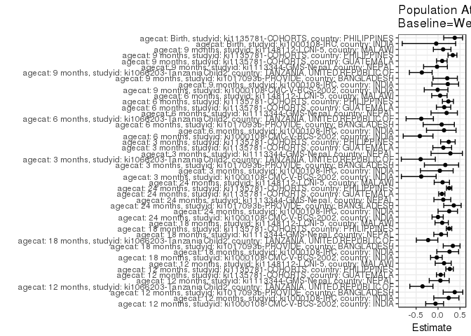

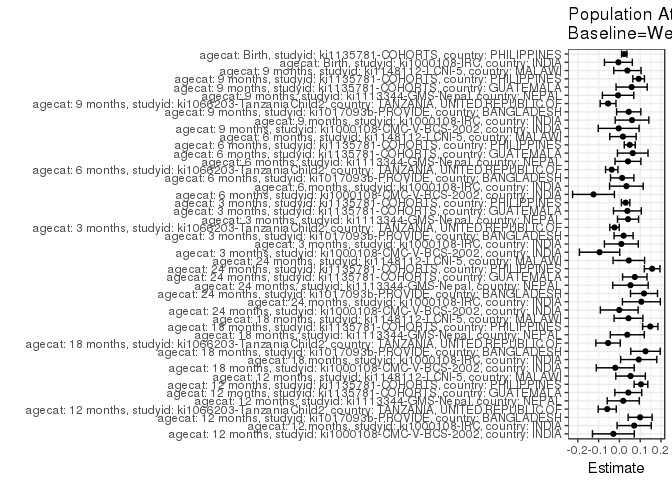

## Results Table

### Parameter: TSM

| agecat | studyid | country | intervention_level | baseline_level | estimate | ci_lower | ci_upper |
| --- | --- | --- | --- | --- | --- | --- | --- |
| Birth | ki1000108-IRC | INDIA | Wealth Q4 | NA | 0.1208791 | 0.0538154 | 0.1879429 |
| Birth | ki1000108-IRC | INDIA | Wealth Q1 | NA | 0.0816327 | 0.0273532 | 0.1359121 |
| Birth | ki1000108-IRC | INDIA | Wealth Q2 | NA | 0.1616162 | 0.0890131 | 0.2342192 |
| Birth | ki1000108-IRC | INDIA | Wealth Q3 | NA | 0.1000000 | 0.0411252 | 0.1588748 |
| Birth | ki1135781-COHORTS | PHILIPPINES | Wealth Q4 | NA | 0.0380048 | 0.0250875 | 0.0509220 |
| Birth | ki1135781-COHORTS | PHILIPPINES | Wealth Q1 | NA | 0.0756914 | 0.0559093 | 0.0954735 |
| Birth | ki1135781-COHORTS | PHILIPPINES | Wealth Q2 | NA | 0.0706320 | 0.0489787 | 0.0922852 |
| Birth | ki1135781-COHORTS | PHILIPPINES | Wealth Q3 | NA | 0.0661914 | 0.0506392 | 0.0817437 |
| 3 months | ki1000108-CMC-V-BCS-2002 | INDIA | Wealth Q4 | NA | 0.3440860 | 0.2473999 | 0.4407722 |
| 3 months | ki1000108-CMC-V-BCS-2002 | INDIA | Wealth Q1 | NA | 0.1444444 | 0.0717164 | 0.2171725 |
| 3 months | ki1000108-CMC-V-BCS-2002 | INDIA | Wealth Q2 | NA | 0.2500000 | 0.1613956 | 0.3386044 |
| 3 months | ki1000108-CMC-V-BCS-2002 | INDIA | Wealth Q3 | NA | 0.2528736 | 0.1614121 | 0.3443350 |
| 3 months | ki1000108-IRC | INDIA | Wealth Q4 | NA | 0.2142857 | 0.1329468 | 0.2956246 |
| 3 months | ki1000108-IRC | INDIA | Wealth Q1 | NA | 0.2190476 | 0.1398396 | 0.2982556 |
| 3 months | ki1000108-IRC | INDIA | Wealth Q2 | NA | 0.2772277 | 0.1898218 | 0.3646336 |
| 3 months | ki1000108-IRC | INDIA | Wealth Q3 | NA | 0.1844660 | 0.1094692 | 0.2594628 |
| 3 months | ki1017093b-PROVIDE | BANGLADESH | Wealth Q4 | NA | 0.1011905 | 0.0555516 | 0.1468294 |
| 3 months | ki1017093b-PROVIDE | BANGLADESH | Wealth Q1 | NA | 0.2138365 | 0.1500564 | 0.2776165 |
| 3 months | ki1017093b-PROVIDE | BANGLADESH | Wealth Q2 | NA | 0.0833333 | 0.0399284 | 0.1267382 |
| 3 months | ki1017093b-PROVIDE | BANGLADESH | Wealth Q3 | NA | 0.0875000 | 0.0436826 | 0.1313174 |
| 3 months | ki1066203-TanzaniaChild2 | TANZANIA, UNITED REPUBLIC OF | Wealth Q4 | NA | 0.0826011 | 0.0599776 | 0.1052245 |
| 3 months | ki1066203-TanzaniaChild2 | TANZANIA, UNITED REPUBLIC OF | Wealth Q1 | NA | 0.0434153 | 0.0282173 | 0.0586134 |
| 3 months | ki1066203-TanzaniaChild2 | TANZANIA, UNITED REPUBLIC OF | Wealth Q2 | NA | 0.0652174 | 0.0426490 | 0.0877858 |
| 3 months | ki1066203-TanzaniaChild2 | TANZANIA, UNITED REPUBLIC OF | Wealth Q3 | NA | 0.0497336 | 0.0317723 | 0.0676948 |
| 3 months | ki1113344-GMS-Nepal | NEPAL | Wealth Q4 | NA | 0.1056338 | 0.0550346 | 0.1562330 |
| 3 months | ki1113344-GMS-Nepal | NEPAL | Wealth Q1 | NA | 0.1643836 | 0.1042129 | 0.2245542 |
| 3 months | ki1113344-GMS-Nepal | NEPAL | Wealth Q2 | NA | 0.1619718 | 0.1013214 | 0.2226222 |
| 3 months | ki1113344-GMS-Nepal | NEPAL | Wealth Q3 | NA | 0.1560284 | 0.0960790 | 0.2159778 |
| 3 months | ki1135781-COHORTS | GUATEMALA | Wealth Q4 | NA | 0.2774566 | 0.2106631 | 0.3442502 |
| 3 months | ki1135781-COHORTS | GUATEMALA | Wealth Q1 | NA | 0.3300971 | 0.2391820 | 0.4210122 |

[output cut: 158 more lines]

### Parameter: E(Y)

| agecat | studyid | country | intervention_level | baseline_level | estimate | ci_lower | ci_upper |
| --- | --- | --- | --- | --- | --- | --- | --- |
| Birth | ki1000108-IRC | INDIA | NA | NA | 0.1159794 | 0.1129891 | 0.1189697 |
| Birth | ki1135781-COHORTS | PHILIPPINES | NA | NA | 0.0613316 | 0.0608055 | 0.0618577 |
| 3 months | ki1000108-CMC-V-BCS-2002 | INDIA | NA | NA | 0.2486188 | 0.2412923 | 0.2559453 |
| 3 months | ki1000108-IRC | INDIA | NA | NA | 0.2235872 | 0.2203210 | 0.2268534 |
| 3 months | ki1017093b-PROVIDE | BANGLADESH | NA | NA | 0.1213064 | 0.1171717 | 0.1254411 |
| 3 months | ki1066203-TanzaniaChild2 | TANZANIA, UNITED REPUBLIC OF | NA | NA | 0.0591327 | 0.0584954 | 0.0597700 |
| 3 months | ki1113344-GMS-Nepal | NEPAL | NA | NA | 0.1471103 | 0.1451355 | 0.1490851 |
| 3 months | ki1135781-COHORTS | GUATEMALA | NA | NA | 0.3156733 | 0.3122738 | 0.3190728 |
| 3 months | ki1135781-COHORTS | PHILIPPINES | NA | NA | 0.1235212 | 0.1227450 | 0.1242974 |
| 6 months | ki1000108-CMC-V-BCS-2002 | INDIA | NA | NA | 0.3008130 | 0.2909205 | 0.3107056 |
| 6 months | ki1000108-IRC | INDIA | NA | NA | 0.2457002 | 0.2406523 | 0.2507482 |
| 6 months | ki1017093b-PROVIDE | BANGLADESH | NA | NA | 0.1617900 | 0.1575394 | 0.1660406 |
| 6 months | ki1066203-TanzaniaChild2 | TANZANIA, UNITED REPUBLIC OF | NA | NA | 0.0965347 | 0.0954809 | 0.0975884 |
| 6 months | ki1113344-GMS-Nepal | NEPAL | NA | NA | 0.2113677 | 0.2093425 | 0.2133928 |
| 6 months | ki1135781-COHORTS | GUATEMALA | NA | NA | 0.4522727 | 0.4473841 | 0.4571614 |
| 6 months | ki1135781-COHORTS | PHILIPPINES | NA | NA | 0.2112260 | 0.2100164 | 0.2124356 |
| 6 months | ki1148112-LCNI-5 | MALAWI | NA | NA | 0.3627451 | 0.3615001 | 0.3639901 |
| 9 months | ki1000108-CMC-V-BCS-2002 | INDIA | NA | NA | 0.3688525 | 0.3602026 | 0.3775023 |
| 9 months | ki1000108-IRC | INDIA | NA | NA | 0.2727273 | 0.2663985 | 0.2790560 |
| 9 months | ki1017093b-PROVIDE | BANGLADESH | NA | NA | 0.2135762 | 0.2079511 | 0.2192012 |
| 9 months | ki1066203-TanzaniaChild2 | TANZANIA, UNITED REPUBLIC OF | NA | NA | 0.1477528 | 0.1460503 | 0.1494553 |
| 9 months | ki1113344-GMS-Nepal | NEPAL | NA | NA | 0.2813067 | 0.2787348 | 0.2838786 |
| 9 months | ki1135781-COHORTS | GUATEMALA | NA | NA | 0.6235566 | 0.6170353 | 0.6300779 |
| 9 months | ki1135781-COHORTS | PHILIPPINES | NA | NA | 0.2750737 | 0.2727631 | 0.2773844 |
| 9 months | ki1148112-LCNI-5 | MALAWI | NA | NA | 0.3302892 | 0.3275570 | 0.3330214 |
| 12 months | ki1000108-CMC-V-BCS-2002 | INDIA | NA | NA | 0.4972826 | 0.4941044 | 0.5004608 |
| 12 months | ki1000108-IRC | INDIA | NA | NA | 0.2931034 | 0.2874931 | 0.2987138 |
| 12 months | ki1017093b-PROVIDE | BANGLADESH | NA | NA | 0.2621035 | 0.2550179 | 0.2691891 |
| 12 months | ki1066203-TanzaniaChild2 | TANZANIA, UNITED REPUBLIC OF | NA | NA | 0.1655076 | 0.1636248 | 0.1673905 |
| 12 months | ki1113344-GMS-Nepal | NEPAL | NA | NA | 0.3422939 | 0.3405406 | 0.3440473 |
| 12 months | ki1135781-COHORTS | GUATEMALA | NA | NA | 0.7045908 | 0.6994140 | 0.7097676 |
| 12 months | ki1135781-COHORTS | PHILIPPINES | NA | NA | 0.3868472 | 0.3841932 | 0.3895012 |
| 12 months | ki1148112-LCNI-5 | MALAWI | NA | NA | 0.3929147 | 0.3898831 | 0.3959462 |
| 18 months | ki1000108-CMC-V-BCS-2002 | INDIA | NA | NA | 0.6883469 | 0.6855236 | 0.6911701 |
| 18 months | ki1000108-IRC | INDIA | NA | NA | 0.3555556 | 0.3502585 | 0.3608526 |
| 18 months | ki1017093b-PROVIDE | BANGLADESH | NA | NA | 0.3720508 | 0.3614933 | 0.3826083 |
| 18 months | ki1066203-TanzaniaChild2 | TANZANIA, UNITED REPUBLIC OF | NA | NA | 0.2415558 | 0.2386239 | 0.2444877 |
| 18 months | ki1113344-GMS-Nepal | NEPAL | NA | NA | 0.5309091 | 0.5286434 | 0.5331747 |
| 18 months | ki1135781-COHORTS | PHILIPPINES | NA | NA | 0.5874799 | 0.5836111 | 0.5913487 |
| 18 months | ki1148112-LCNI-5 | MALAWI | NA | NA | 0.4589708 | 0.4569460 | 0.4609956 |
| 24 months | ki1000108-CMC-V-BCS-2002 | INDIA | NA | NA | 0.7150538 | 0.7106902 | 0.7194173 |
| 24 months | ki1000108-IRC | INDIA | NA | NA | 0.4156479 | 0.4081552 | 0.4231407 |
| 24 months | ki1017093b-PROVIDE | BANGLADESH | NA | NA | 0.3298611 | 0.3201969 | 0.3395253 |
| 24 months | ki1113344-GMS-Nepal | NEPAL | NA | NA | 0.4468938 | 0.4434314 | 0.4503561 |
| 24 months | ki1135781-COHORTS | GUATEMALA | NA | NA | 0.8350101 | 0.8293290 | 0.8406911 |
| 24 months | ki1135781-COHORTS | PHILIPPINES | NA | NA | 0.6167689 | 0.6128216 | 0.6207162 |
| 24 months | ki1148112-LCNI-5 | MALAWI | NA | NA | 0.4390244 | 0.4362578 | 0.4417910 |

### Parameter: RR

| agecat | studyid | country | intervention_level | baseline_level | estimate | ci_lower | ci_upper |
| --- | --- | --- | --- | --- | --- | --- | --- |
| Birth | ki1000108-IRC | INDIA | Wealth Q4 | Wealth Q4 | 1.0000000 | 1.0000000 | 1.0000000 |
| Birth | ki1000108-IRC | INDIA | Wealth Q1 | Wealth Q4 | 0.6753247 | 0.2840672 | 1.6054774 |
| Birth | ki1000108-IRC | INDIA | Wealth Q2 | Wealth Q4 | 1.3370064 | 0.6547919 | 2.7300066 |
| Birth | ki1000108-IRC | INDIA | Wealth Q3 | Wealth Q4 | 0.8272727 | 0.3683993 | 1.8577130 |
| Birth | ki1135781-COHORTS | PHILIPPINES | Wealth Q4 | Wealth Q4 | 1.0000000 | 1.0000000 | 1.0000000 |
| Birth | ki1135781-COHORTS | PHILIPPINES | Wealth Q1 | Wealth Q4 | 1.9916303 | 1.2971947 | 3.0578225 |
| Birth | ki1135781-COHORTS | PHILIPPINES | Wealth Q2 | Wealth Q4 | 1.8585037 | 1.1759273 | 2.9372872 |
| Birth | ki1135781-COHORTS | PHILIPPINES | Wealth Q3 | Wealth Q4 | 1.7416624 | 1.1521723 | 2.6327556 |
| 3 months | ki1000108-CMC-V-BCS-2002 | INDIA | Wealth Q4 | Wealth Q4 | 1.0000000 | 1.0000000 | 1.0000000 |
| 3 months | ki1000108-CMC-V-BCS-2002 | INDIA | Wealth Q1 | Wealth Q4 | 0.4197917 | 0.2358403 | 0.7472220 |
| 3 months | ki1000108-CMC-V-BCS-2002 | INDIA | Wealth Q2 | Wealth Q4 | 0.7265625 | 0.4622153 | 1.1420935 |
| 3 months | ki1000108-CMC-V-BCS-2002 | INDIA | Wealth Q3 | Wealth Q4 | 0.7349138 | 0.4648617 | 1.1618472 |
| 3 months | ki1000108-IRC | INDIA | Wealth Q4 | Wealth Q4 | 1.0000000 | 1.0000000 | 1.0000000 |
| 3 months | ki1000108-IRC | INDIA | Wealth Q1 | Wealth Q4 | 1.0222222 | 0.6051548 | 1.7267289 |
| 3 months | ki1000108-IRC | INDIA | Wealth Q2 | Wealth Q4 | 1.2937294 | 0.7898478 | 2.1190610 |
| 3 months | ki1000108-IRC | INDIA | Wealth Q3 | Wealth Q4 | 0.8608414 | 0.4935854 | 1.5013572 |
| 3 months | ki1017093b-PROVIDE | BANGLADESH | Wealth Q4 | Wealth Q4 | 1.0000000 | 1.0000000 | 1.0000000 |
| 3 months | ki1017093b-PROVIDE | BANGLADESH | Wealth Q1 | Wealth Q4 | 2.1132075 | 1.2305784 | 3.6289002 |
| 3 months | ki1017093b-PROVIDE | BANGLADESH | Wealth Q2 | Wealth Q4 | 0.8235294 | 0.4134784 | 1.6402325 |
| 3 months | ki1017093b-PROVIDE | BANGLADESH | Wealth Q3 | Wealth Q4 | 0.8647059 | 0.4407393 | 1.6965045 |
| 3 months | ki1066203-TanzaniaChild2 | TANZANIA, UNITED REPUBLIC OF | Wealth Q4 | Wealth Q4 | 1.0000000 | 1.0000000 | 1.0000000 |
| 3 months | ki1066203-TanzaniaChild2 | TANZANIA, UNITED REPUBLIC OF | Wealth Q1 | Wealth Q4 | 0.5256028 | 0.3369960 | 0.8197673 |
| 3 months | ki1066203-TanzaniaChild2 | TANZANIA, UNITED REPUBLIC OF | Wealth Q2 | Wealth Q4 | 0.7895467 | 0.5078252 | 1.2275563 |
| 3 months | ki1066203-TanzaniaChild2 | TANZANIA, UNITED REPUBLIC OF | Wealth Q3 | Wealth Q4 | 0.6020937 | 0.3826628 | 0.9473532 |
| 3 months | ki1113344-GMS-Nepal | NEPAL | Wealth Q4 | Wealth Q4 | 1.0000000 | 1.0000000 | 1.0000000 |
| 3 months | ki1113344-GMS-Nepal | NEPAL | Wealth Q1 | Wealth Q4 | 1.5561644 | 0.8516088 | 2.8436150 |
| 3 months | ki1113344-GMS-Nepal | NEPAL | Wealth Q2 | Wealth Q4 | 1.5333333 | 0.8348090 | 2.8163461 |
| 3 months | ki1113344-GMS-Nepal | NEPAL | Wealth Q3 | Wealth Q4 | 1.4770686 | 0.7993129 | 2.7295089 |
| 3 months | ki1135781-COHORTS | GUATEMALA | Wealth Q4 | Wealth Q4 | 1.0000000 | 1.0000000 | 1.0000000 |
| 3 months | ki1135781-COHORTS | GUATEMALA | Wealth Q1 | Wealth Q4 | 1.1897249 | 0.8252431 | 1.7151859 |

[output cut: 158 more lines]

### Parameter: PAR

| agecat | studyid | country | intervention_level | baseline_level | estimate | ci_lower | ci_upper |
| --- | --- | --- | --- | --- | --- | --- | --- |
| Birth | ki1000108-IRC | INDIA | Wealth Q4 | NA | -0.0048997 | -0.0720301 | 0.0622306 |
| Birth | ki1135781-COHORTS | PHILIPPINES | Wealth Q4 | NA | 0.0233268 | 0.0103989 | 0.0362548 |
| 3 months | ki1000108-CMC-V-BCS-2002 | INDIA | Wealth Q4 | NA | -0.0954672 | -0.1924306 | 0.0014961 |
| 3 months | ki1000108-IRC | INDIA | Wealth Q4 | NA | 0.0093015 | -0.0721029 | 0.0907059 |
| 3 months | ki1017093b-PROVIDE | BANGLADESH | Wealth Q4 | NA | 0.0201159 | -0.0257099 | 0.0659417 |
| 3 months | ki1066203-TanzaniaChild2 | TANZANIA, UNITED REPUBLIC OF | Wealth Q4 | NA | -0.0234683 | -0.0461008 | -0.0008359 |
| 3 months | ki1113344-GMS-Nepal | NEPAL | Wealth Q4 | NA | 0.0414765 | -0.0091612 | 0.0921143 |
| 3 months | ki1135781-COHORTS | GUATEMALA | Wealth Q4 | NA | 0.0382166 | -0.0286634 | 0.1050966 |
| 3 months | ki1135781-COHORTS | PHILIPPINES | Wealth Q4 | NA | 0.0299688 | 0.0096568 | 0.0502807 |
| 6 months | ki1000108-CMC-V-BCS-2002 | INDIA | Wealth Q4 | NA | -0.1247189 | -0.2252924 | -0.0241454 |
| 6 months | ki1000108-IRC | INDIA | Wealth Q4 | NA | 0.0335790 | -0.0472069 | 0.1143650 |
| 6 months | ki1017093b-PROVIDE | BANGLADESH | Wealth Q4 | NA | 0.0134029 | -0.0427694 | 0.0695753 |
| 6 months | ki1066203-TanzaniaChild2 | TANZANIA, UNITED REPUBLIC OF | Wealth Q4 | NA | -0.0369315 | -0.0667066 | -0.0071563 |
| 6 months | ki1113344-GMS-Nepal | NEPAL | Wealth Q4 | NA | 0.0411549 | -0.0209656 | 0.1032754 |
| 6 months | ki1135781-COHORTS | GUATEMALA | Wealth Q4 | NA | 0.0640374 | -0.0094681 | 0.1375430 |
| 6 months | ki1135781-COHORTS | PHILIPPINES | Wealth Q4 | NA | 0.0497186 | 0.0232255 | 0.0762117 |
| 6 months | ki1148112-LCNI-5 | MALAWI | Wealth Q4 | NA | 0.0171230 | -0.0462032 | 0.0804492 |
| 9 months | ki1000108-CMC-V-BCS-2002 | INDIA | Wealth Q4 | NA | -0.0034880 | -0.1017307 | 0.0947547 |
| 9 months | ki1000108-IRC | INDIA | Wealth Q4 | NA | 0.0606061 | -0.0202700 | 0.1414822 |
| 9 months | ki1017093b-PROVIDE | BANGLADESH | Wealth Q4 | NA | 0.0448262 | -0.0135268 | 0.1031791 |
| 9 months | ki1066203-TanzaniaChild2 | TANZANIA, UNITED REPUBLIC OF | Wealth Q4 | NA | -0.0545728 | -0.0925926 | -0.0165530 |
| 9 months | ki1113344-GMS-Nepal | NEPAL | Wealth Q4 | NA | -0.0064631 | -0.0818370 | 0.0689108 |
| 9 months | ki1135781-COHORTS | GUATEMALA | Wealth Q4 | NA | 0.0588507 | -0.0160491 | 0.1337505 |
| 9 months | ki1135781-COHORTS | PHILIPPINES | Wealth Q4 | NA | 0.0925234 | 0.0646832 | 0.1203636 |
| 9 months | ki1148112-LCNI-5 | MALAWI | Wealth Q4 | NA | 0.0383973 | -0.0272218 | 0.1040164 |
| 12 months | ki1000108-CMC-V-BCS-2002 | INDIA | Wealth Q4 | NA | -0.0290332 | -0.1296248 | 0.0715584 |
| 12 months | ki1000108-IRC | INDIA | Wealth Q4 | NA | 0.0708812 | -0.0113055 | 0.1530680 |
| 12 months | ki1017093b-PROVIDE | BANGLADESH | Wealth Q4 | NA | 0.0996035 | 0.0419566 | 0.1572504 |
| 12 months | ki1066203-TanzaniaChild2 | TANZANIA, UNITED REPUBLIC OF | Wealth Q4 | NA | -0.0585820 | -0.1018924 | -0.0152716 |
| 12 months | ki1113344-GMS-Nepal | NEPAL | Wealth Q4 | NA | 0.0183502 | -0.0587103 | 0.0954108 |
| 12 months | ki1135781-COHORTS | GUATEMALA | Wealth Q4 | NA | 0.0427551 | -0.0219636 | 0.1074737 |
| 12 months | ki1135781-COHORTS | PHILIPPINES | Wealth Q4 | NA | 0.1036980 | 0.0707674 | 0.1366286 |
| 12 months | ki1148112-LCNI-5 | MALAWI | Wealth Q4 | NA | 0.0537334 | -0.0173475 | 0.1248142 |
| 18 months | ki1000108-CMC-V-BCS-2002 | INDIA | Wealth Q4 | NA | -0.0199864 | -0.1110769 | 0.0711040 |
| 18 months | ki1000108-IRC | INDIA | Wealth Q4 | NA | 0.0929293 | 0.0059757 | 0.1798829 |
| 18 months | ki1017093b-PROVIDE | BANGLADESH | Wealth Q4 | NA | 0.1254755 | 0.0547057 | 0.1962453 |
| 18 months | ki1066203-TanzaniaChild2 | TANZANIA, UNITED REPUBLIC OF | Wealth Q4 | NA | -0.0545816 | -0.1133068 | 0.0041437 |
| 18 months | ki1113344-GMS-Nepal | NEPAL | Wealth Q4 | NA | 0.0378535 | -0.0439095 | 0.1196166 |
| 18 months | ki1135781-COHORTS | PHILIPPINES | Wealth Q4 | NA | 0.1483865 | 0.1115678 | 0.1852051 |
| 18 months | ki1148112-LCNI-5 | MALAWI | Wealth Q4 | NA | 0.0435862 | -0.0256573 | 0.1128297 |
| 24 months | ki1000108-CMC-V-BCS-2002 | INDIA | Wealth Q4 | NA | -0.0007357 | -0.0916609 | 0.0901895 |
| 24 months | ki1000108-IRC | INDIA | Wealth Q4 | NA | 0.1056479 | 0.0145811 | 0.1967147 |
| 24 months | ki1017093b-PROVIDE | BANGLADESH | Wealth Q4 | NA | 0.1183226 | 0.0534559 | 0.1831894 |
| 24 months | ki1113344-GMS-Nepal | NEPAL | Wealth Q4 | NA | 0.0531930 | -0.0319341 | 0.1383201 |
| 24 months | ki1135781-COHORTS | GUATEMALA | Wealth Q4 | NA | 0.0740344 | 0.0153183 | 0.1327506 |
| 24 months | ki1135781-COHORTS | PHILIPPINES | Wealth Q4 | NA | 0.1574666 | 0.1200129 | 0.1949203 |
| 24 months | ki1148112-LCNI-5 | MALAWI | Wealth Q4 | NA | 0.0452744 | -0.0305471 | 0.1210959 |

### Parameter: PAF

| agecat | studyid | country | intervention_level | baseline_level | estimate | ci_lower | ci_upper |
| --- | --- | --- | --- | --- | --- | --- | --- |
| Birth | ki1000108-IRC | INDIA | Wealth Q4 | NA | -0.0422466 | -0.8162562 | 0.4019136 |
| Birth | ki1135781-COHORTS | PHILIPPINES | Wealth Q4 | NA | 0.3803397 | 0.1294164 | 0.5589408 |
| 3 months | ki1000108-CMC-V-BCS-2002 | INDIA | Wealth Q4 | NA | -0.3839904 | -0.8358473 | -0.0433491 |
| 3 months | ki1000108-IRC | INDIA | Wealth Q4 | NA | 0.0416013 | -0.4012589 | 0.3444979 |
| 3 months | ki1017093b-PROVIDE | BANGLADESH | Wealth Q4 | NA | 0.1658272 | -0.3112632 | 0.4693329 |
| 3 months | ki1066203-TanzaniaChild2 | TANZANIA, UNITED REPUBLIC OF | Wealth Q4 | NA | -0.3968756 | -0.8373756 | -0.0619829 |
| 3 months | ki1113344-GMS-Nepal | NEPAL | Wealth Q4 | NA | 0.2819416 | -0.1595006 | 0.5553191 |
| 3 months | ki1135781-COHORTS | GUATEMALA | Wealth Q4 | NA | 0.1210639 | -0.1184376 | 0.3092787 |
| 3 months | ki1135781-COHORTS | PHILIPPINES | Wealth Q4 | NA | 0.2426203 | 0.0590261 | 0.3903933 |
| 6 months | ki1000108-CMC-V-BCS-2002 | INDIA | Wealth Q4 | NA | -0.4146061 | -0.7938079 | -0.1155656 |
| 6 months | ki1000108-IRC | INDIA | Wealth Q4 | NA | 0.1366667 | -0.2632709 | 0.4099884 |
| 6 months | ki1017093b-PROVIDE | BANGLADESH | Wealth Q4 | NA | 0.0828415 | -0.3389766 | 0.3717741 |
| 6 months | ki1066203-TanzaniaChild2 | TANZANIA, UNITED REPUBLIC OF | Wealth Q4 | NA | -0.3825723 | -0.7283455 | -0.1059746 |
| 6 months | ki1113344-GMS-Nepal | NEPAL | Wealth Q4 | NA | 0.1947077 | -0.1599070 | 0.4409071 |
| 6 months | ki1135781-COHORTS | GUATEMALA | Wealth Q4 | NA | 0.1415903 | -0.0372245 | 0.2895779 |
| 6 months | ki1135781-COHORTS | PHILIPPINES | Wealth Q4 | NA | 0.2353810 | 0.0991461 | 0.3510133 |
| 6 months | ki1148112-LCNI-5 | MALAWI | Wealth Q4 | NA | 0.0472039 | -0.1443837 | 0.2067167 |
| 9 months | ki1000108-CMC-V-BCS-2002 | INDIA | Wealth Q4 | NA | -0.0094563 | -0.3142723 | 0.2246645 |
| 9 months | ki1000108-IRC | INDIA | Wealth Q4 | NA | 0.2222222 | -0.1382559 | 0.4685393 |
| 9 months | ki1017093b-PROVIDE | BANGLADESH | Wealth Q4 | NA | 0.2098837 | -0.1158495 | 0.4405305 |
| 9 months | ki1066203-TanzaniaChild2 | TANZANIA, UNITED REPUBLIC OF | Wealth Q4 | NA | -0.3693518 | -0.6527100 | -0.1345756 |
| 9 months | ki1113344-GMS-Nepal | NEPAL | Wealth Q4 | NA | -0.0229752 | -0.3292921 | 0.2127553 |
| 9 months | ki1135781-COHORTS | GUATEMALA | Wealth Q4 | NA | 0.0943791 | -0.0339745 | 0.2067994 |
| 9 months | ki1135781-COHORTS | PHILIPPINES | Wealth Q4 | NA | 0.3363586 | 0.2272505 | 0.4300612 |
| 9 months | ki1148112-LCNI-5 | MALAWI | Wealth Q4 | NA | 0.1162536 | -0.1064742 | 0.2941473 |
| 12 months | ki1000108-CMC-V-BCS-2002 | INDIA | Wealth Q4 | NA | -0.0583837 | -0.2813041 | 0.1257532 |
| 12 months | ki1000108-IRC | INDIA | Wealth Q4 | NA | 0.2418301 | -0.0970514 | 0.4760303 |
| 12 months | ki1017093b-PROVIDE | BANGLADESH | Wealth Q4 | NA | 0.3800159 | 0.1174723 | 0.5644553 |
| 12 months | ki1066203-TanzaniaChild2 | TANZANIA, UNITED REPUBLIC OF | Wealth Q4 | NA | -0.3539533 | -0.6428846 | -0.1158359 |
| 12 months | ki1113344-GMS-Nepal | NEPAL | Wealth Q4 | NA | 0.0536096 | -0.2005454 | 0.2539601 |
| 12 months | ki1135781-COHORTS | GUATEMALA | Wealth Q4 | NA | 0.0606807 | -0.0357750 | 0.1481541 |
| 12 months | ki1135781-COHORTS | PHILIPPINES | Wealth Q4 | NA | 0.2680594 | 0.1779303 | 0.3483070 |
| 12 months | ki1148112-LCNI-5 | MALAWI | Wealth Q4 | NA | 0.1367558 | -0.0644515 | 0.2999300 |
| 18 months | ki1000108-CMC-V-BCS-2002 | INDIA | Wealth Q4 | NA | -0.0290354 | -0.1702574 | 0.0951445 |
| 18 months | ki1000108-IRC | INDIA | Wealth Q4 | NA | 0.2613636 | -0.0282555 | 0.4694085 |
| 18 months | ki1017093b-PROVIDE | BANGLADESH | Wealth Q4 | NA | 0.3372536 | 0.1185161 | 0.5017121 |
| 18 months | ki1066203-TanzaniaChild2 | TANZANIA, UNITED REPUBLIC OF | Wealth Q4 | NA | -0.2259584 | -0.4950375 | -0.0053085 |
| 18 months | ki1113344-GMS-Nepal | NEPAL | Wealth Q4 | NA | 0.0712995 | -0.0962020 | 0.2132065 |
| 18 months | ki1135781-COHORTS | PHILIPPINES | Wealth Q4 | NA | 0.2525813 | 0.1873728 | 0.3125572 |
| 18 months | ki1148112-LCNI-5 | MALAWI | Wealth Q4 | NA | 0.0949650 | -0.0691915 | 0.2339181 |
| 24 months | ki1000108-CMC-V-BCS-2002 | INDIA | Wealth Q4 | NA | -0.0010289 | -0.1366172 | 0.1183850 |
| 24 months | ki1000108-IRC | INDIA | Wealth Q4 | NA | 0.2541765 | -0.0000560 | 0.4437784 |
| 24 months | ki1017093b-PROVIDE | BANGLADESH | Wealth Q4 | NA | 0.3587045 | 0.1303219 | 0.5271124 |
| 24 months | ki1113344-GMS-Nepal | NEPAL | Wealth Q4 | NA | 0.1190283 | -0.0935761 | 0.2902998 |
| 24 months | ki1135781-COHORTS | GUATEMALA | Wealth Q4 | NA | 0.0886629 | 0.0156214 | 0.1562848 |
| 24 months | ki1135781-COHORTS | PHILIPPINES | Wealth Q4 | NA | 0.2553089 | 0.1922018 | 0.3134859 |
| 24 months | ki1148112-LCNI-5 | MALAWI | Wealth Q4 | NA | 0.1031250 | -0.0873011 | 0.2602006 |